# AI Text Mining

Cansu Tatar

5/22/2021

```
## Building corpus...
## Converting to Lower Case...
## Removing punctuation...
## Removing stopwords...
## Removing numbers...
## Stemming...
## Creating Output...
```

## Introduction

**Purpose:** The purpose of this project is to explore the trends related to Artificial Intelligence in the New York Times newspaper from 1986 to 2016.The media plays a powerful role to control the public perceptions.Understanding of the media’s attitude toward AI can help to understand people’s perspectives likewise.

**Data Sources:** As data source, this project used the Fast & Horvitz (2016) AI news annotated dataset. This dataset includes the AI article information in the New York Times. You can find the overview of the dataset below.

**Target Audience:** This analysis may help AI educators and researchers who want to develop educational learning activities related to text mining classification task. They can use this analysis as an example to reveal possible learning opportunities.

```
## Rows: 17,073
## Columns: 7
## $ ID               <chr> "4fd1cbc98eb7c8105d701286", "4fd1cbc98eb7c8105d70128…
## $ Date             <chr> "1996-10-06 00:00:00 UTC", "1996-10-06 00:00:00 UTC"…
## $ Paragraph_number <dbl> 18, 18, 18, 16, 16, 16, 16, 16, 16, 3, 3, 3, 16, 16,…
## $ Section          <chr> "New York and Region", "New York and Region", "New Y…
## $ Paragraph        <chr> "Thus, next weekend will feature the robot who is na…
## $ Title            <chr> "LONG ISLAND JOURNAL", "LONG ISLAND JOURNAL", "LONG …
## $ AI_mood          <dbl> 4, 4, 5, 3, 3, 4, 4, 3, 4, 3, 3, 3, 5, 3, 4, 3, 3, 3…
```

## Preparing the Data

Before starting the analysis, I cleaned the data. The paragraphs were annotated by three different person, therefore they were repeated three times. For this reason, I have created a data frame and remove the dublicated paragraphs.

```r
ai_duplicated<- distinct(ai_public_new,ID,Date,Paragraph_number,Section,Paragraph, Title)
glimpse(ai_duplicated)
```

```
## Rows: 5,690
## Columns: 6
## $ ID               <chr> "4fd1cbc98eb7c8105d701286", "54b0793b7988100e2196577…
## $ Date             <chr> "1996-10-06 00:00:00 UTC", "2006-07-31 00:00:00 UTC"…
## $ Paragraph_number <dbl> 18, 16, 16, 3, 16, 20, 12, 26, 26, 29, 8, 8, 10, 8, …
## $ Section          <chr> "New York and Region", "Technology", "Technology", "…
## $ Paragraph        <chr> "Thus, next weekend will feature the robot who is na…
## $ Title            <chr> "LONG ISLAND JOURNAL", "Camera System Creates Sophis…
```

## Methods

1. Visualize Data: Basic word counts, bar graphs frequencies
2. Topic modeling using LDA
3. Topic modeling using STM
4. Sentiment analysis
5. Reading the Tea Leaves

## Visualize Data: Basic word counts, bar graphs frequencies

###Term Frequency-Inverse Document Frequency

```
## # A tibble: 3,200 x 2
##    Title                                              total
##  * <chr>                                              <int>
##  1 ... or More Modern, High-Tech Pursuits                86
##  2 'Al Gore Has a Beard'                                 65
##  3 'American Idol': There's Got to Be a Morning After   132
##  4 'ASSASSIN,' A CBS MOVIE ABOUT A KILLER ROBOT          97
##  5 'Better Call Saul' Recap: Help a Nacho Out            35
##  6 'BIG FLOYD' JOINS THE FORCE                          111
##  7 'Cartoons Come to Paterson'                           72
##  8 'Double' Turns the iPad Into a Telepresence Robot    125
##  9 'Dressed Like the Mayor'                              99
## 10 'Eureka!' Off Gibraltar: A Trove From 1694?           61
## # … with 3,190 more rows
```

```
## # A tibble: 6 x 7
##   Title                                word        n total     tf    idf  tf_idf
##   <chr>                                <chr>   <int> <int>  <dbl>  <dbl>   <dbl>
## 1 Examining AOL's Apology              the       838 15004 0.0559 0.0612 0.00342
## 2 Electing the New Congress: Races fo… distri…   416  5281 0.0788 5.87   0.463
## 3 Examining AOL's Apology              to        408 15004 0.0272 0.247  0.00673
## 4 Electing the New Congress: Races fo… r         378  5281 0.0716 4.06   0.291
## 5 Electing the New Congress: Races fo… d         369  5281 0.0699 3.90   0.272
## 6 Examining AOL's Apology              of        362 15004 0.0241 0.208  0.00503
```

### WordCloud

[interactive chart not shown]

### Bar Chart

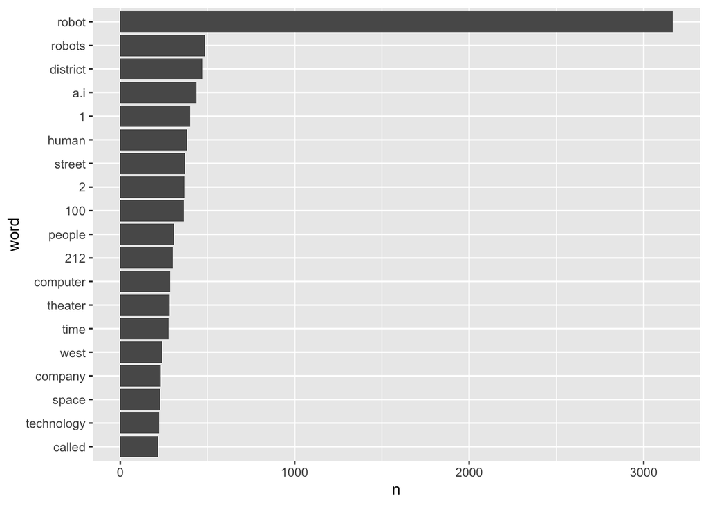

### Frequencies

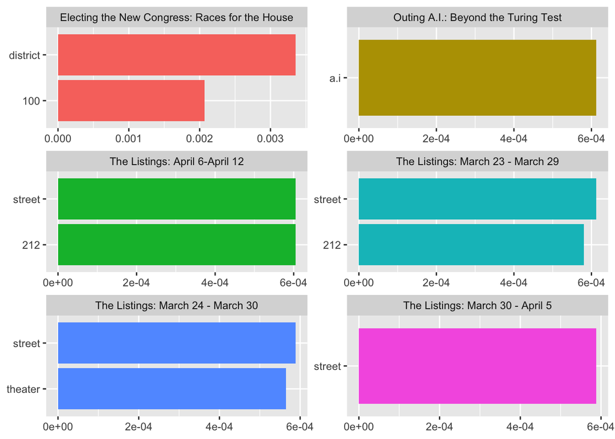

### Showing in Multiple Graphs

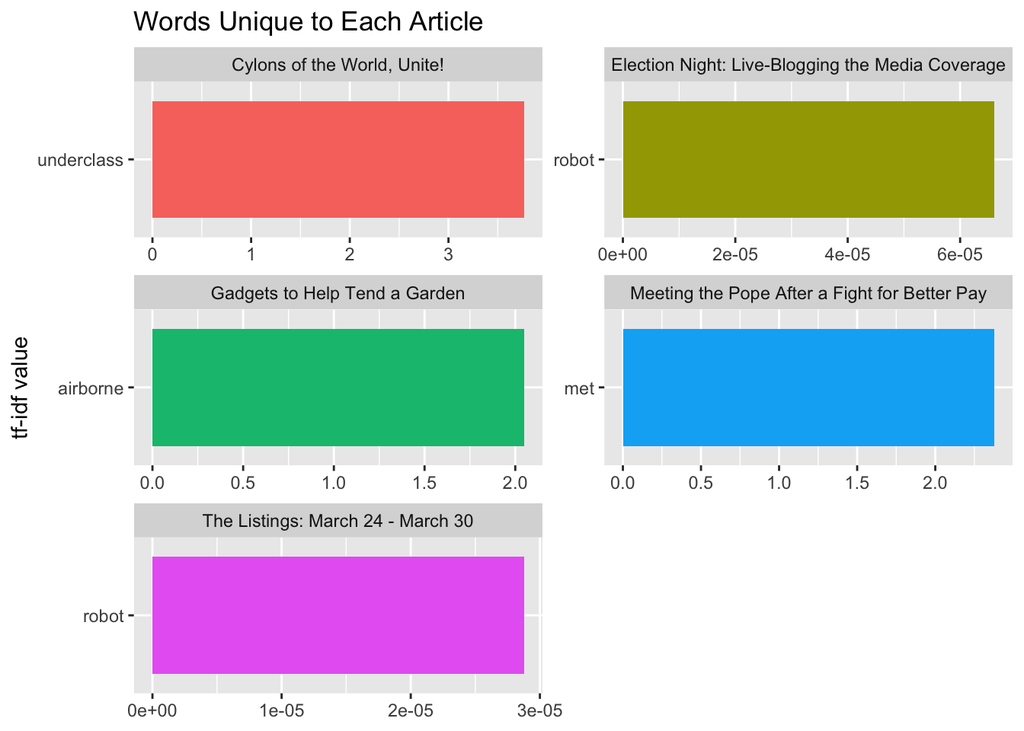

## Topic Modeling with LDA

Before LDA model, I kept wrangling process by stemming tidy text.

```r
stemmed_ai
```

```
## <<DocumentTermMatrix (documents: 3367, terms: 22592)>>
## Non-/sparse entries: 154147/75913117
## Sparsity           : 100%
## Maximal term length: NA
## Weighting          : term frequency (tf)
```

```r
stemmed_dtm_ai
```

```
## <<DocumentTermMatrix (documents: 30401, terms: 22592)>>
## Non-/sparse entries: 30401/686788991
## Sparsity           : 100%
## Maximal term length: NA
## Weighting          : term frequency (tf)
```

Let’s find the number of title with distinct function.

```r
n_distinct(ai_public_removed$Title)
```

```
## [1] 3200
```

```r
ai_lda<- LDA(ai_dtm,
              k = 20,
              control = list(seed = 588)
)

ai_lda
```

```
## A LDA_VEM topic model with 20 topics.
```

## Topic Modeling with STM

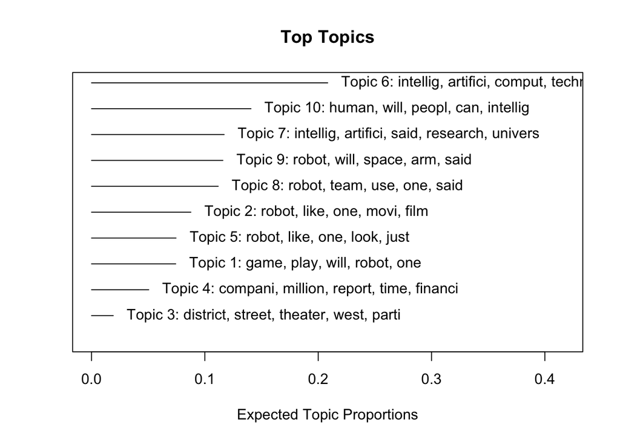

```r
docs <- temp$documents
meta <- temp$meta
vocab <- temp$vocab

ai_stm <- stm(documents=docs,
                          data=meta,
                          vocab=vocab,
                          K=10,
                          max.em.its=25,
                          verbose = FALSE)

plot.STM(ai_stm, n = 5)
```

### Finding K

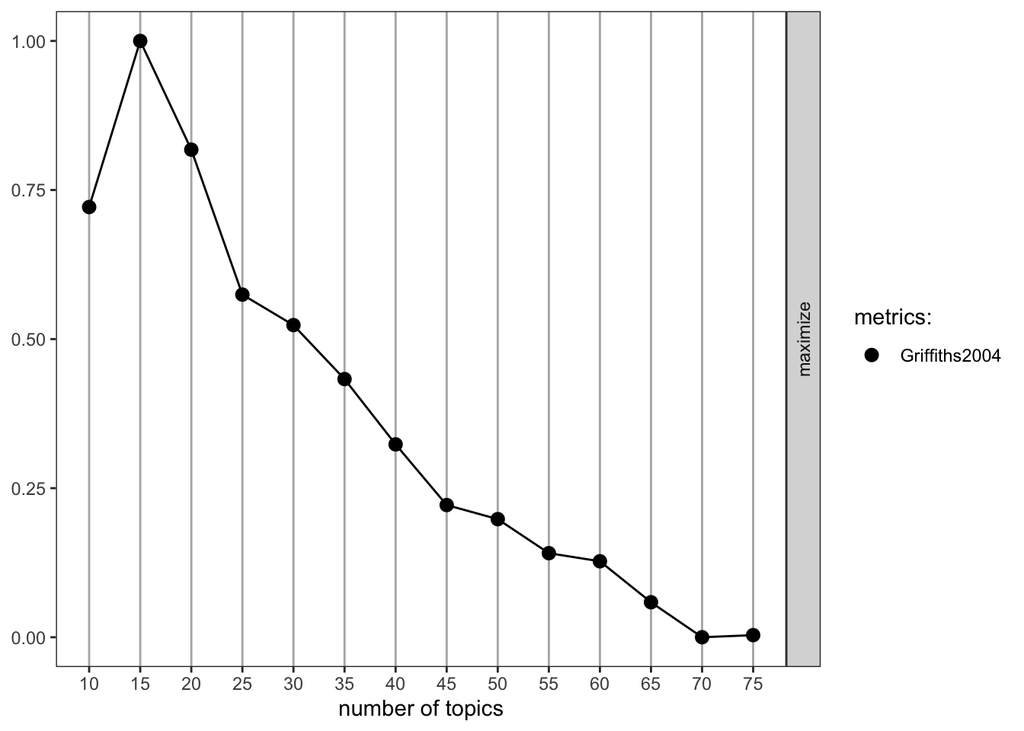

###The LDAvis Explorer

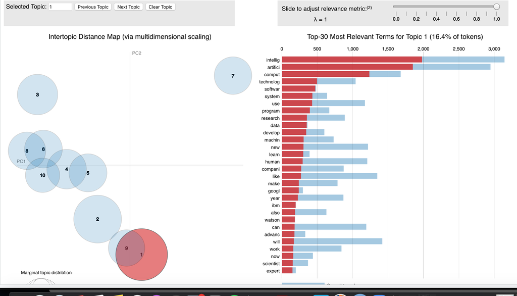

## Sentiment Analysis Using Bing

```
## # A tibble: 121 x 5
## # Groups:   Section [121]
##    lexicon Section               negative positive sentiment
##    <chr>   <chr>                    <int>    <int>     <int>
##  1 bing    Arts                       486      435       -51
##  2 bing    Arts; Books                 70       72         2
##  3 bing    Arts; Books; Opinion         3        3         0
##  4 bing    Arts; Obituaries             4       NA        NA
##  5 bing    Arts; Style; Magazine       NA        1        NA
##  6 bing    Arts; Theater               16       10        -6
##  7 bing    Automobiles                  8       12         4
##  8 bing    Autos                       19       11        -8
##  9 bing    Blogs                       27       17       -10
## 10 bing    Books                      147       82       -65
## # … with 111 more rows
```

```
## # A tibble: 2,390 x 5
## # Groups:   word [2,390]
##    lexicon word      negative positive sentiment
##    <chr>   <chr>        <int>    <int>     <int>
##  1 bing    abolish          2       NA        NA
##  2 bing    aborted          5       NA        NA
##  3 bing    abound          NA        1        NA
##  4 bing    abrasive         3       NA        NA
##  5 bing    abrupt           1       NA        NA
##  6 bing    abruptly         1       NA        NA
##  7 bing    absence          2       NA        NA
##  8 bing    absurd           1       NA        NA
##  9 bing    absurdity        1       NA        NA
## 10 bing    absurdly         1       NA        NA
## # … with 2,380 more rows
```

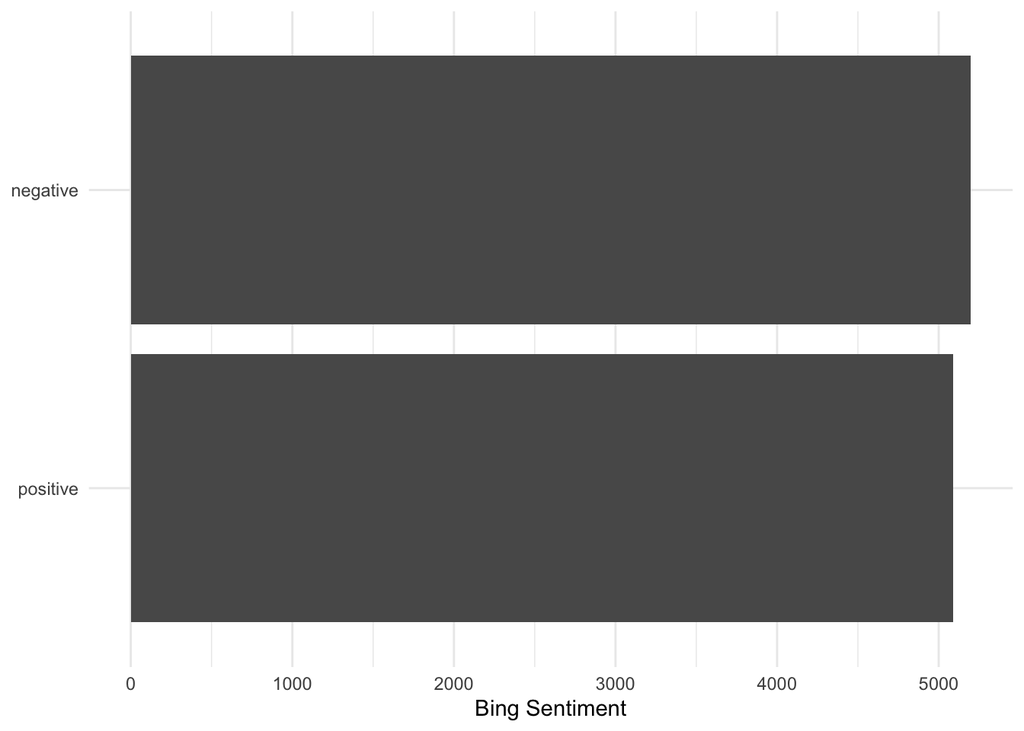